# Lecture 10 - Tree Classification

Joseph Haymaker

11/8/2017

# Tree based methods

### Part II: RandomForest for classifications

##### 1) Single Trees

##### 2) Random Forests

(Notice, RF for classification is similar to that of regression RF’s. May skip this and please go through the code for 1) and 2))

##### 3) Appendix 1: Deviance and Gini index in details

##### 4) Appendix 2. Random classifiers

Load all packages

```r
if (!require("pacman")) install.packages("pacman")
```

```r
pacman::p_load(randomForest, tree, rpart, pROC, partykit)
#install.packages('rattle')
#install.packages('rpart.plot')
library(randomForest)
library(tree)
library(rpart)
library(rpart.plot)
library(pROC)
library(partykit)
# library(rattle)
#library(rpart.plot)
```

### Part II: RandomForeset for classifications

Random Forest for classification is similar to that of regression trees except for the criterion used for growing a tree is different.

Algorithm:

```
-For b=1 to B
  I) Take a bootstrap sample of size n
  II) Build a tree T_b, using the bootstrap sample recursively until the n_min is met
      i) Randomly select m variables
      ii) For each variable, find the best split point such that the misclassification errors is minimized by majority vote
      iii) Find the best variable and split point, split the node into two
      iv) The end node will output the majority vote either 0 or 1
 -Output the trees {T_1, T_2, ... T_B}
 -The final aggregated tree will report the prop. of 1's among B trees
```

##### Remarks on the splitting criterion.

- Suppose $(n_1, p_1)$ and $(n_2, p_2)$ are the number of obs’n and sample prop of “1”’s on the left and right split point

Three criteria are commonly used i) Mis classification errors for majority vote (RF uses) $ (n_1* min(p_1, 1-p_1) + n_2* min(p_2, 1-p_2))/n $

(MisClassification errors are $min(p_1, 1-p_1)$ in the left region and $min(p_2, 1-p_2)$ on the right side)

2. Deviance:  
   $ -2loglik =-2*(n1*p1*log(p1)+ n1*(1-p1)*log(1-p1) + n2*p2*log(p2)+ n2*(1-p2)*log(1-p2)) $
3. Gini index $2(p_1 (1-p_1) + p_2( 1-p_2))$ (we skip this)

*Gini index*: misclassification errors for a random procedure that assign hat y=“1” with prob. p_1

#### Framingham data for classification trees for simplicity

```r
rm(list=ls()) # Remove all the existing variables
data <- read.table("Framingham.dat", sep=",", header=T, as.is=T)
data1 <- na.omit(data)    # no missing value
names(data1)[1] <- "HD"
data1$HD <- as.factor(data1$HD)
data1$SEX <- as.factor(data1$SEX)
table(as.factor(data1$CIG))  # The levels are very unbalanced. We combine those CIG >35 together and
```

```
##
##   0   1   5  10  15  20  25  30  35  40  45  50  60
## 766  28 123  55  60 228  25  51  13  28   2  12   2
```

```r
# make CIG a categorical variable
data1$CIG[data1$CIG > 35] <- 40
data1$CIG <- as.factor(data1$CIG)
str(data1)
```

```
## 'data.frame':    1393 obs. of  8 variables:
##  $ HD  : Factor w/ 2 levels "0","1": 1 1 1 1 1 1 1 1 1 1 ...
##  $ AGE : int  45 49 47 48 49 47 48 48 46 45 ...
##  $ SEX : Factor w/ 2 levels "FEMALE","MALE": 2 2 2 2 2 2 2 2 2 2 ...
##  $ SBP : int  90 100 100 108 108 108 108 110 110 110 ...
##  $ DBP : int  50 64 70 70 75 68 70 70 80 72 ...
##  $ CHOL: int  216 237 215 340 149 165 196 229 204 183 ...
##  $ FRW : int  76 97 86 93 95 88 79 85 112 93 ...
##  $ CIG : Factor w/ 10 levels "0","1","5","10",..: 3 1 10 1 1 1 6 7 1 6 ...
##  - attr(*, "na.action")=Class 'omit'  Named int [1:14] 41 112 376 434 658 660 761 939 1090 1105 ...
##   .. ..- attr(*, "names")= chr [1:14] "41" "112" "376" "434" ...
```

### 1): A single tree using package tree

*Note this package is different from RandomForest

##### a) Use SBP alone to see the effect of two different criteria: deviance and gini

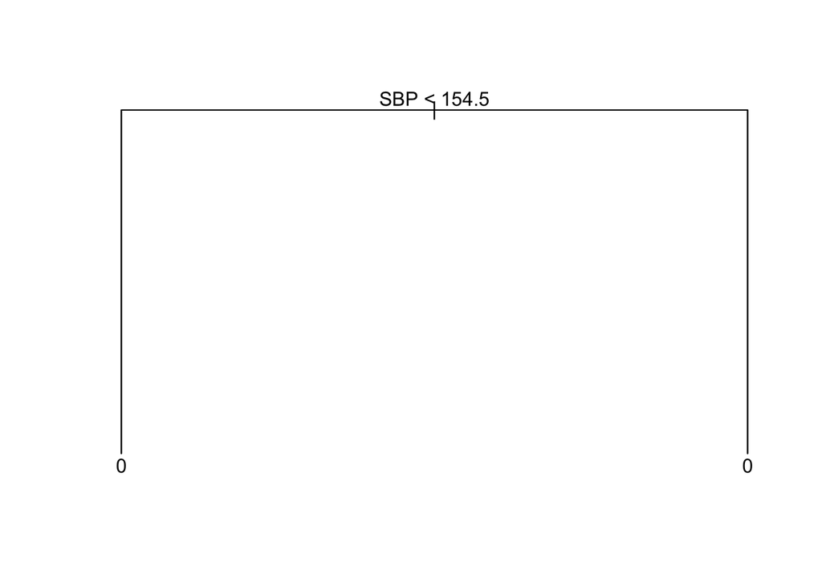

```r
fit.dev <- tree(HD~SBP, data1,
                control=tree.control(nrow(data1), mindev = 0.01),
                split="deviance")
#split = c("deviance", "gini"), "deviance" as default.
plot(fit.dev)
text(fit.dev, pretty=TRUE)  # plot the labels
```

```r
fit.dev$frame
```

```
##      var    n       dev yval splits.cutleft splits.cutright   yprob.0
## 1    SBP 1393 1469.3313    0         <154.5          >154.5 0.7796123
## 2 <leaf>  923  829.0482    0                                0.8342362
## 3 <leaf>  470  594.5583    0                                0.6723404
##     yprob.1
## 1 0.2203877
## 2 0.1657638
## 3 0.3276596
```

```
 var    n       dev yval splits.cutleft splits.cutright   yprob.0   yprob.1
 1    SBP 1393 1469.3313    0         <154.5          >154.5 0.7796123 0.2203877
 2 <leaf>  923  829.0482    0                                0.8342362 0.1657638
 3 <leaf>  470  594.5583    0                                0.6723404 0.3276596
```

##### b) Use all predictors

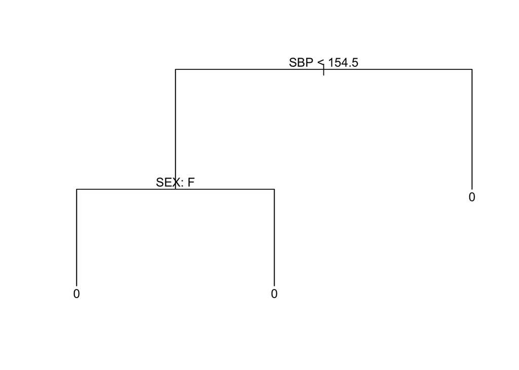

```r
fit.tree <- tree(HD~., data1)
plot(fit.tree)
text(fit.tree, pretty=TRUE)  # plot the labels
```

```r
fit.tree$frame
```

```
##      var    n       dev yval splits.cutleft splits.cutright    yprob.0
## 1    SBP 1393 1469.3313    0         <154.5          >154.5 0.77961235
## 2    SEX  923  829.0482    0             :a              :b 0.83423619
## 4 <leaf>  444  268.8386    0                                0.90990991
## 5 <leaf>  479  523.3719    0                                0.76409186
## 3 <leaf>  470  594.5583    0                                0.67234043
##      yprob.1
## 1 0.22038765
## 2 0.16576381
## 4 0.09009009
## 5 0.23590814
## 3 0.32765957
```

```r
# yprob.1=sample prop of 1's in the end node
# yval is majority vote class
# we can set our own rules by thresholding yprob
```

**Use ROC/AUC ect. to measure the performance**

```r
predict(fit.tree, data1)[1:20, ]
```

```
##            0         1
## 1  0.7640919 0.2359081
## 2  0.7640919 0.2359081
## 3  0.7640919 0.2359081
## 4  0.7640919 0.2359081
## 5  0.7640919 0.2359081
## 6  0.7640919 0.2359081
## 7  0.7640919 0.2359081
## 8  0.7640919 0.2359081
## 9  0.7640919 0.2359081
## 10 0.7640919 0.2359081
## 11 0.7640919 0.2359081
## 12 0.7640919 0.2359081
## 13 0.7640919 0.2359081
## 14 0.7640919 0.2359081
## 15 0.7640919 0.2359081
## 16 0.7640919 0.2359081
## 17 0.7640919 0.2359081
## 18 0.7640919 0.2359081
## 19 0.7640919 0.2359081
## 20 0.7640919 0.2359081
```

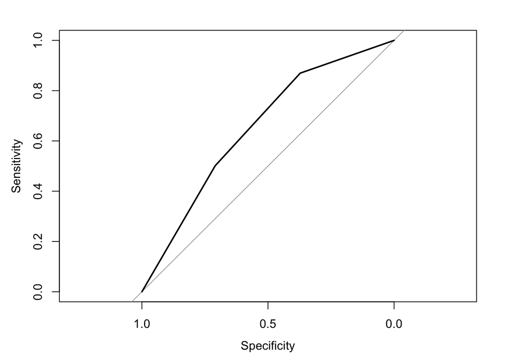

```
##
## Call:
## roc.default(response = data1$HD, predictor = prob.1, plot = T)
##
## Data: prob.1 in 1086 controls (data1$HD 0) < 307 cases (data1$HD 1).
## Area under the curve: 0.6518
```

```r
prob.1 <- predict(fit.tree, data1)[, 2] # Prob(y=1|x)
roc(data1$HD, prob.1, plot=T) # since there are only three values for hat P(y=1)
```

##### c) A single tree with categorical predictors

To convince you that trees take categorical var. Grow a tree with only `CIG`+`SBP` (Obviously from b), `CIG` didn’t get in)

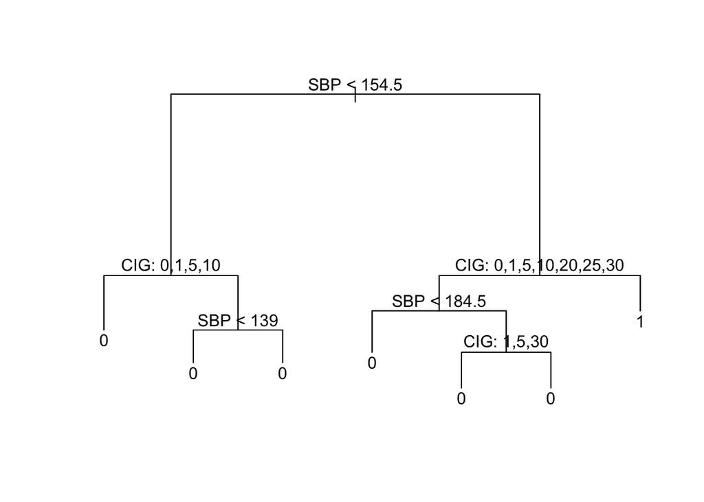

```r
fit.tree <- tree(HD~CIG+SBP, data1, control=tree.control(nrow(data1), mindev = 0.005))
plot(fit.tree)
text(fit.tree, pretty=TRUE)
```

```r
fit.tree$frame
```

```
##       var    n         dev yval splits.cutleft splits.cutright    yprob.0
## 1     SBP 1393 1469.331281    0         <154.5          >154.5 0.77961235
## 2     CIG  923  829.048170    0          :abcd         :efghij 0.83423619
## 4  <leaf>  616  483.275547    0                                0.86688312
## 5     SBP  307  332.055363    0           <139            >139 0.76872964
## 10 <leaf>  200  188.557395    0                                0.82000000
## 11 <leaf>  107  135.271085    0                                0.67289720
## 3     CIG  470  594.558252    0       :abcdfgh            :eij 0.67234043
## 6     SBP  432  533.421583    0         <184.5          >184.5 0.69212963
## 12 <leaf>  318  367.197175    0                                0.73584906
## 13    CIG  114  155.784512    0           :bch           :adfg 0.57017544
## 26 <leaf>   13    7.050924    0                                0.92307692
## 27 <leaf>  101  139.768105    0                                0.52475248
## 7  <leaf>   38   52.257352    1                                0.44736842
##       yprob.1
## 1  0.22038765
## 2  0.16576381
## 4  0.13311688
## 5  0.23127036
## 10 0.18000000
## 11 0.32710280
## 3  0.32765957
## 6  0.30787037
## 12 0.26415094
## 13 0.42982456
## 26 0.07692308
## 27 0.47524752
## 7  0.55263158
```

```r
(unique(as.factor(round(predict(fit.tree)[, 2], 5)))) # To check it agrees with fit.tree$frame
```

```
## [1] 0.13312 0.18    0.3271  0.26415 0.55263 0.47525 0.07692
## Levels: 0.07692 0.13312 0.18 0.26415 0.3271 0.47525 0.55263
```

##### d) Package rpart

Use package rpart, together with rattle or partykid we can get a better tree displays.

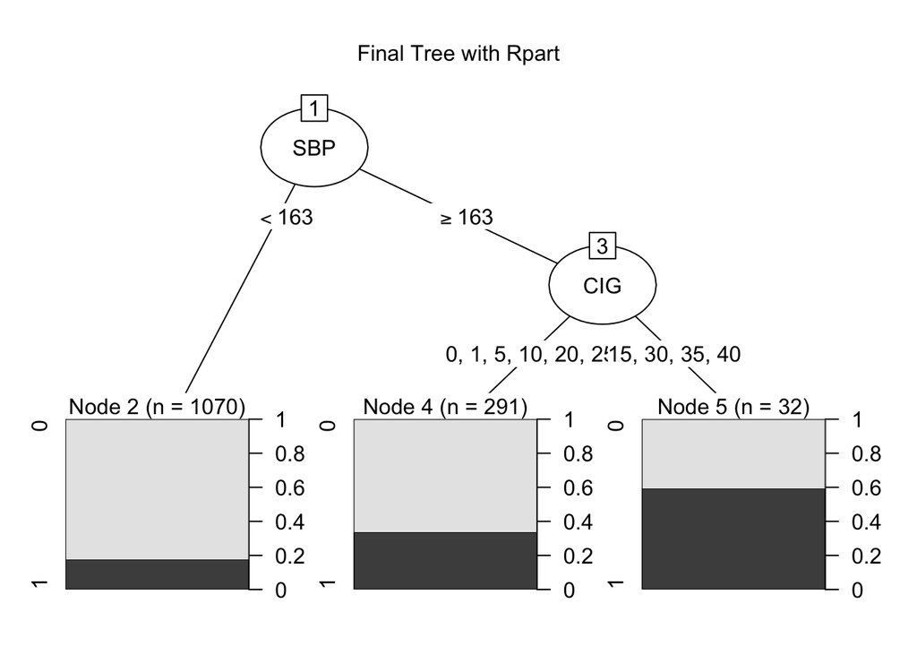

```r
fit.tree <- rpart(HD~., data1, minsplit=1, cp=9e-3)
fit.tree <- rpart(HD~CIG+SBP, data1, minsplit=1, cp=9e-3)
    # cp is similar to mindev in tree()
    # control=rpart.control(cp=-1, minbucket=1), method="class")
plot(as.party(fit.tree), main="Final Tree with Rpart") # method 1
```

```r
#fancyRpartPlot(fit.tree)   # The plot shows the split together with more information # method 2
fit.tree$frame
```

```
##      var    n   wt dev yval  complexity ncompete nsurrogate     yval2.V1
## 1    SBP 1393 1393 307    1 0.009771987        1          0    1.0000000
## 2 <leaf> 1070 1070 190    1 0.000000000        0          0    1.0000000
## 3    CIG  323  323 117    1 0.009771987        1          1    1.0000000
## 6 <leaf>  291  291  98    1 0.006514658        0          0    1.0000000
## 7 <leaf>   32   32  13    2 0.000000000        0          0    2.0000000
##       yval2.V2     yval2.V3     yval2.V4     yval2.V5 yval2.nodeprob
## 1 1086.0000000  307.0000000    0.7796123    0.2203877      1.0000000
## 2  880.0000000  190.0000000    0.8224299    0.1775701      0.7681263
## 3  206.0000000  117.0000000    0.6377709    0.3622291      0.2318737
## 6  193.0000000   98.0000000    0.6632302    0.3367698      0.2089017
## 7   13.0000000   19.0000000    0.4062500    0.5937500      0.0229720
```

### 2): Random Forests

##### 1) First run only a few trees

```r
set.seed(1)
fit.rf <- randomForest(HD~., data1, mtry=4, ntree=4)
```

Mis-classification rates of OOB, misclassification errors for “0” and “1”

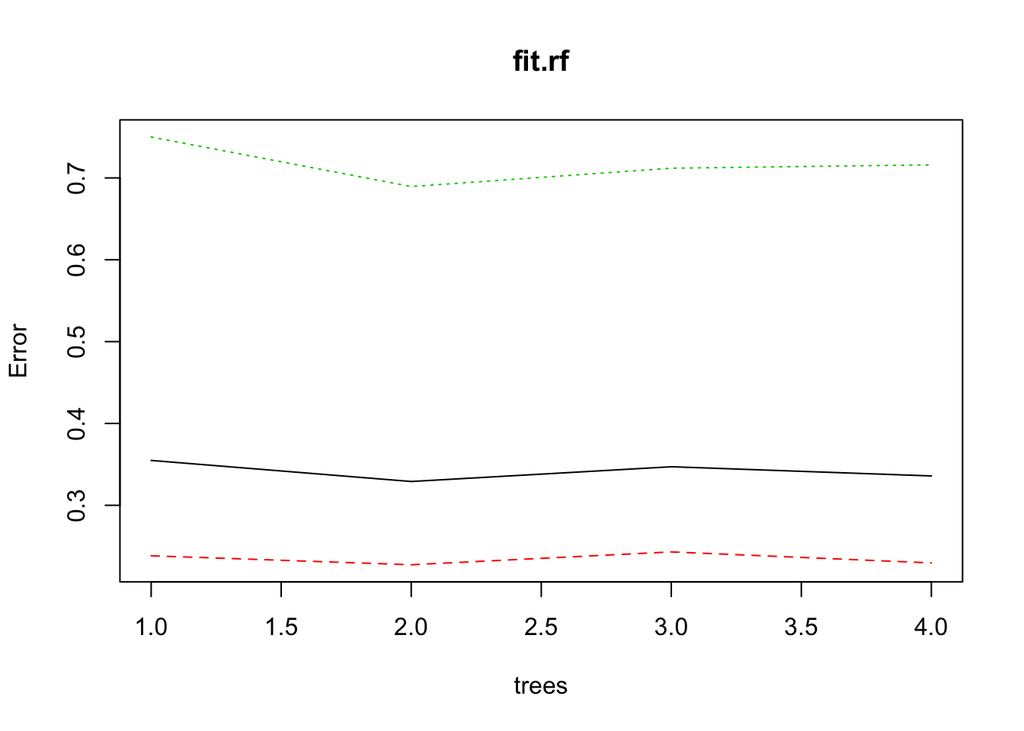

```r
plot(fit.rf)
```

The output

```r
names(fit.rf)
```

```
##  [1] "call"            "type"            "predicted"
##  [4] "err.rate"        "confusion"       "votes"
##  [7] "oob.times"       "classes"         "importance"
## [10] "importanceSD"    "localImportance" "proximity"
## [13] "ntree"           "mtry"            "forest"
## [16] "y"               "test"            "inbag"
## [19] "terms"
```

```r
fit.rf$mtry
```

```
## [1] 4
```

```r
fit.rf$votes[1:20, ]   #  prob of 0 and 1 using oob's
```

```
##            0         1
## 1  1.0000000 0.0000000
## 2  1.0000000 0.0000000
## 3        NaN       NaN
## 4  0.0000000 1.0000000
## 5  1.0000000 0.0000000
## 6  0.0000000 1.0000000
## 7  1.0000000 0.0000000
## 8        NaN       NaN
## 9  1.0000000 0.0000000
## 10 0.5000000 0.5000000
## 11 1.0000000 0.0000000
## 12       NaN       NaN
## 13 1.0000000 0.0000000
## 14 1.0000000 0.0000000
## 15 1.0000000 0.0000000
## 16 1.0000000 0.0000000
## 17 0.5000000 0.5000000
## 18 0.6666667 0.3333333
## 19 1.0000000 0.0000000
## 20       NaN       NaN
```

```r
fit.rf$predicted[1:20] #  lables using oob's and majority vote. Notice those with NA because they are not in any OOB's
```

```
##    1    2    3    4    5    6    7    8    9   10   11   12   13   14   15
##    0    0 <NA>    1    0    1    0 <NA>    0    0    0 <NA>    0    0    0
##   16   17   18   19   20
##    0    0    0    0 <NA>
## Levels: 0 1
```

```r
fit.rf$err.rate #      #  mis-classification errors of oob's/0/1
```

```
##            OOB         0         1
## [1,] 0.3548387 0.2383292 0.7500000
## [2,] 0.3290846 0.2273403 0.6894737
## [3,] 0.3471308 0.2430472 0.7118644
## [4,] 0.3358844 0.2295974 0.7159533
```

```r
predict(fit.rf, data1)[1:20]  # prediction by using the RF based on all the training data.
```

```
##  1  2  3  4  5  6  7  8  9 10 11 12 13 14 15 16 17 18 19 20
##  0  0  0  1  0  0  0  0  0  0  0  0  0  0  0  0  0  0  0  0
## Levels: 0 1
```

```r
data.frame(fit.rf$votes[1:20, ], fit.rf$predicted[1:20], predict(fit.rf, data1)[1:20] )
```

```
##           X0        X1 fit.rf.predicted.1.20. predict.fit.rf..data1..1.20.
## 1  1.0000000 0.0000000                      0                            0
## 2  1.0000000 0.0000000                      0                            0
## 3        NaN       NaN                   <NA>                            0
## 4  0.0000000 1.0000000                      1                            1
## 5  1.0000000 0.0000000                      0                            0
## 6  0.0000000 1.0000000                      1                            1
## 7  1.0000000 0.0000000                      0                            0
## 8        NaN       NaN                   <NA>                            0
## 9  1.0000000 0.0000000                      0                            0
## 10 0.5000000 0.5000000                      0                            0
## 11 1.0000000 0.0000000                      0                            0
## 12       NaN       NaN                   <NA>                            0
## 13 1.0000000 0.0000000                      0                            0
## 14 1.0000000 0.0000000                      0                            0
## 15 1.0000000 0.0000000                      0                            0
## 16 1.0000000 0.0000000                      0                            0
## 17 0.5000000 0.5000000                      0                            0
## 18 0.6666667 0.3333333                      0                            0
## 19 1.0000000 0.0000000                      0                            0
## 20       NaN       NaN                   <NA>                            0
```

### 2) RandomForest, more general

```r
fit.rf <- randomForest(HD~., data1, mtry=4, ntree=500 )
#fit.rf=randomForest(HD~., data.fram, cutoff=c(.5, .5), ntree=500)
```

**default settings**:

- mtry=p/3, (sqrt(p) in classification tree)
- Bootstrap size B=ntree=500

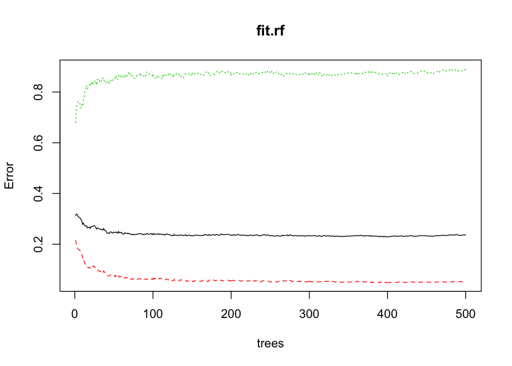

```r
plot(fit.rf)        # Three curves of MCE of 1's, 0's and  overall.
```

```r
fit.rf.pred <- predict(fit.rf, type="prob")  # output the prob of "0" and "1")
fit.rf.pred.y <- predict(fit.rf, type="response")
mean(data1$HD != fit.rf.pred.y)  # Training misclassification error is about .23
```

```
## [1] 0.2361809
```

#### 3) using training and testing data

```r
n <- nrow(data1)
n1 <- (2/3)*n
train.index <- sample(n, n1,replace=FALSE)
length(train.index)
```

```
## [1] 928
```

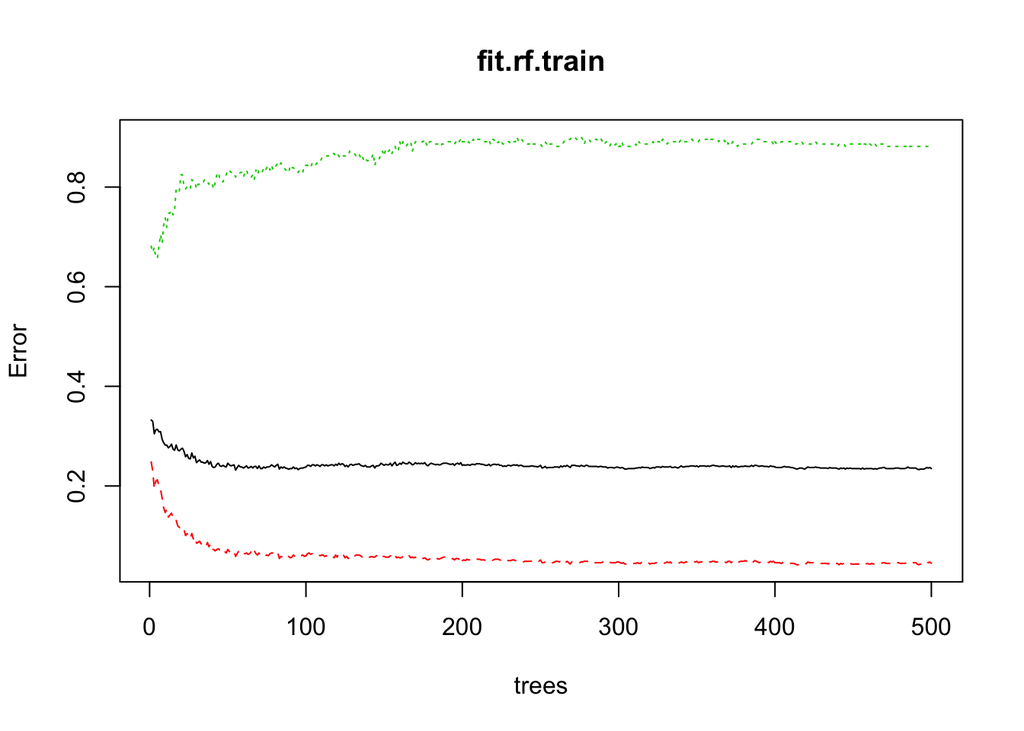

```r
data.train <- data1[train.index, ]
data.test <- data1[-train.index, ]

fit.rf.train <- randomForest(HD~., data.train)
plot(fit.rf.train)
```

```r
predict.rf.y <- predict(fit.rf.train, newdata=data.test)   # labels
predict.rf <- predict(fit.rf.train, newdata=data.test, type="prob")  #probabilities
```

##### Testing errors

```r
mean(data.test$HD != predict.rf.y)   # about .24
```

```
## [1] 0.2344086
```

##### Testing ROC curve

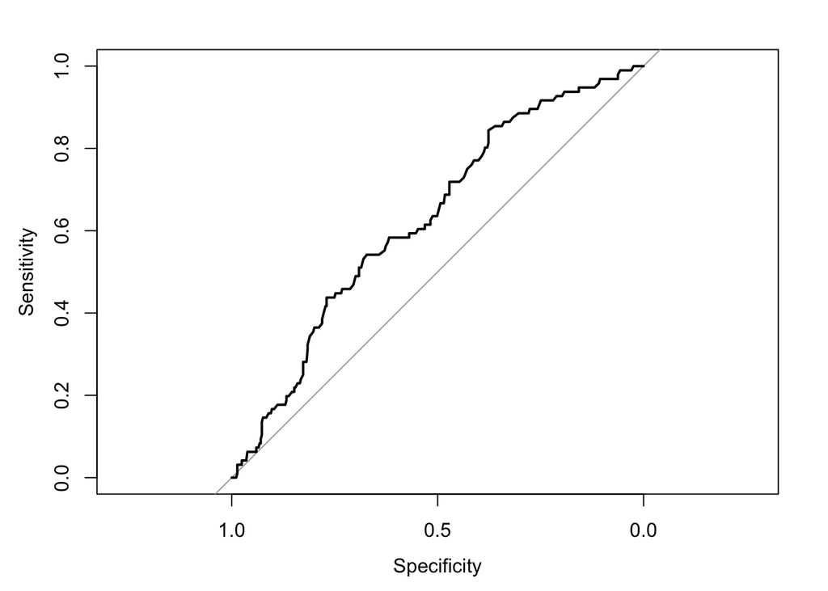

```
##
## Call:
## roc.default(response = data.test$HD, predictor = predict.rf[,     2], plot = TRUE)
##
## Data: predict.rf[, 2] in 369 controls (data.test$HD 0) < 96 cases (data.test$HD 1).
## Area under the curve: 0.6286
```

```r
roc(data.test$HD, predict.rf[,2], plot=TRUE)  # Ok
```

**Comments about RF classifications**

**Pro:** + pretty accurate; fast; robust to number of variables; + not very sensitive to outliers. + It handles automatically multi-categories in response.

**Con:** + loose interpretation, may discriminate against categorical predictors.

Extremely cautious about: + Importance plot + The validity of using a cut off point other than 1/2, though we can still set our own thresholds.

**We will see how other competitors work**

## Appendix 1: Deviance and Gini index in details

Use `SBP` alone to see the effect of two different criteria: *deviance* and *gini*

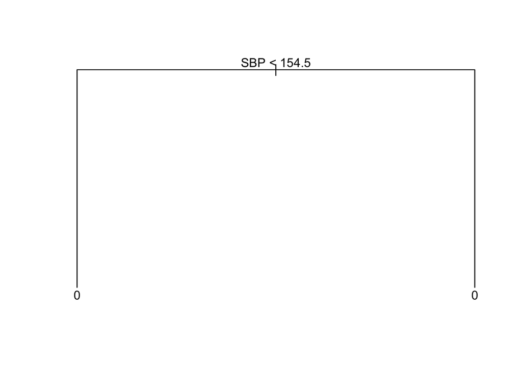

```r
fit.dev <- tree(HD~SBP, data1, split="deviance")
#split <-  c("deviance", "gini"), "deviance" as default.
plot(fit.dev)
text(fit.dev, pretty=TRUE)  # plot the labels
```

```r
fit.dev$frame
```

```
##      var    n       dev yval splits.cutleft splits.cutright   yprob.0
## 1    SBP 1393 1469.3313    0         <154.5          >154.5 0.7796123
## 2 <leaf>  923  829.0482    0                                0.8342362
## 3 <leaf>  470  594.5583    0                                0.6723404
##     yprob.1
## 1 0.2203877
## 2 0.1657638
## 3 0.3276596
```

```
 var    n       dev yval splits.cutleft splits.cutright   yprob.0   yprob.1
 1    SBP 1393 1469.3313    0         <154.5          >154.5 0.7796123 0.2203877
 2 <leaf>  923  829.0482    0                                0.8342362 0.1657638
 3 <leaf>  470  594.5583    0                                0.6723404 0.3276596
```

```r
summary(fit.dev)
```

```
##
## Classification tree:
## tree(formula = HD ~ SBP, data = data1, split = "deviance")
## Number of terminal nodes:  2
## Residual mean deviance:  1.023 = 1424 / 1391
## Misclassification error rate: 0.2204 = 307 / 1393
```

Residual mean deviance: 1.023 = 1424 / 1391

Use above output, we recover the mean dev above: -2loglik/(n-number of nodes)

```r
p1 <- 0.1657638        # sample prop of Y=1 when SBP <154.5
n1 <- 923
n1* p1              # number of Y=1 when SBP < 154.5
```

```
## [1] 153
```

```r
n1*(1-p1)           # number of Y=0 when SBP < 154.5
```

```
## [1] 770
```

```r
p2 <- 0.3276596        # sample prop of Y=1 when SBP <154.5
n2 <- 470
n2*p2               # number of Y=1 when SBP > 154.5
```

```
## [1] 154
```

```r
n2*(1-p2)           # number of Y=0 when SBP > 154.5
```

```
## [1] 316
```

```r
dev <- -2*(n1*p1*log(p1)+ n1*(1-p1)*log(1-p1) +
          n2*p2*log(p2)+ n2*(1-p2)*log(1-p2))
dev/(1393-2)
```

```
## [1] 1.023441
```

```r
# [1] 1.023441   agrees with the summary output
```

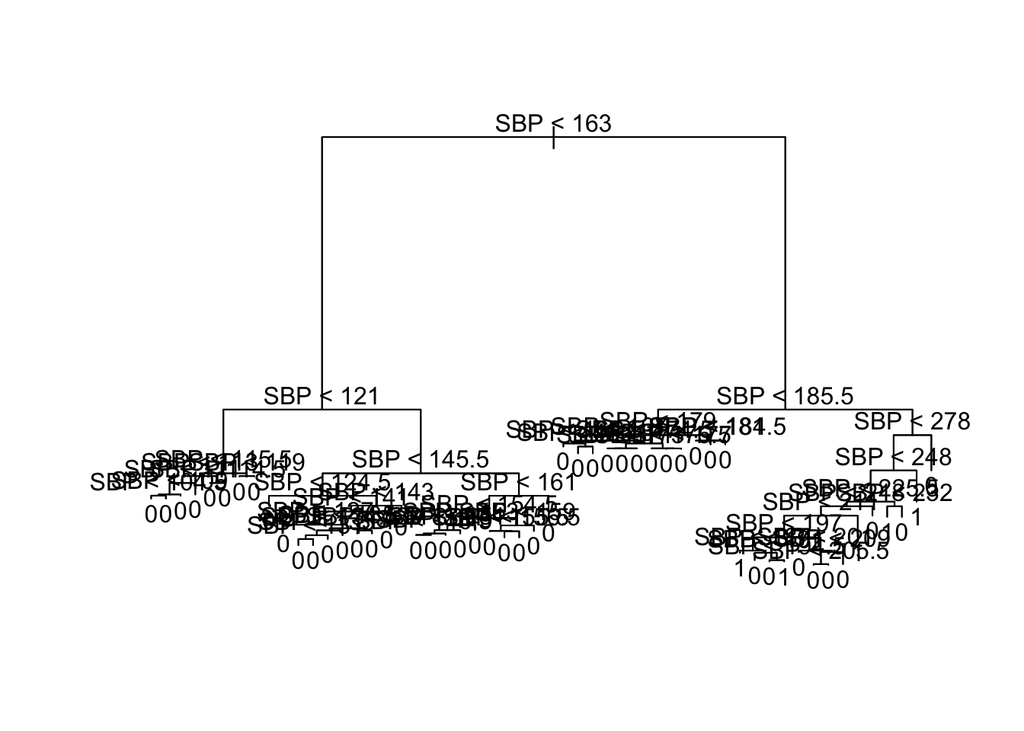

```r
fit.gini <- tree(HD~SBP, data1, split="gini")  #split = c("deviance", "gini") as an option
plot(fit.gini)
text(fit.gini, pretty=TRUE)  # plot the labels
```

```r
head(fit.gini$frame, 30)
```

```
##         var    n         dev yval splits.cutleft splits.cutright
## 1       SBP 1393 1469.331281    0           <163            >163
## 2       SBP 1070 1000.854100    0           <121            >121
## 4       SBP  190  123.531530    0         <115.5          >115.5
## 8       SBP   96   68.350443    0           <113            >113
## 16      SBP   74   46.330081    0           <111            >111
## 32      SBP   65   44.416214    0           <109            >109
## 64      SBP   32   24.113290    0         <104.5          >104.5
## 128  <leaf>   13    7.050924    0
## 129  <leaf>   19   16.574168    0
## 65   <leaf>   33   20.105982    0
## 33   <leaf>    9    0.000000    0
## 17      SBP   22   20.862130    0         <114.5          >114.5
## 34   <leaf>   16   15.442482    0
## 35   <leaf>    6    5.406735    0
```

[output cut: 47 more lines]

```r
summary(fit.gini)
```

```
##
## Classification tree:
## tree(formula = HD ~ SBP, data = data1, split = "gini")
## Number of terminal nodes:  54
## Residual mean deviance:  1.011 = 1354 / 1339
## Misclassification error rate: 0.2096 = 292 / 1393
```

We notice that two trees are different.

## Appendix 2. Random classiferes

- Assign Y = 1 with prob of P(Y=1),
- Similarly assigning Y= 0 with prob of P(Y=0)

The misclassificaiton error will be same as gini index.

We use the following tree to demonstrate how to produce a random procedure and also to compare the **mis-classification errors (MCE)** between the majority vote and the random procedure.

##### We use fit.gini to construct two sets of classifiers.

```r
fit.gini <- tree(HD~SBP, data1, split="gini")  #split = c("deviance", "gini") as an option
phat <- predict(fit.gini, data1 ) # estimated prob
```

**1) Majority vote rules:**

```r
y.5 <- ifelse(phat>0.5, "1", "0")
mean(data1$HD != y.5)       ## It's about .5
```

```
## [1] 0.5
```

**2) Use a random procedure yhat=“1” with prob phat**

```r
n <- nrow(data1)
y.rand <- rep(0,n )
for (i in 1:n) {
  y.rand[i] <- rbinom(1, 1, phat[i, 2])
}

mean(data1$HD != y.rand)   # mis-classification errors
```

```
## [1] 0.3230438
```

```r
#[1] 0.3201723   # it's about .3
```

## Appendix 3. Tree split in action (a toy example)

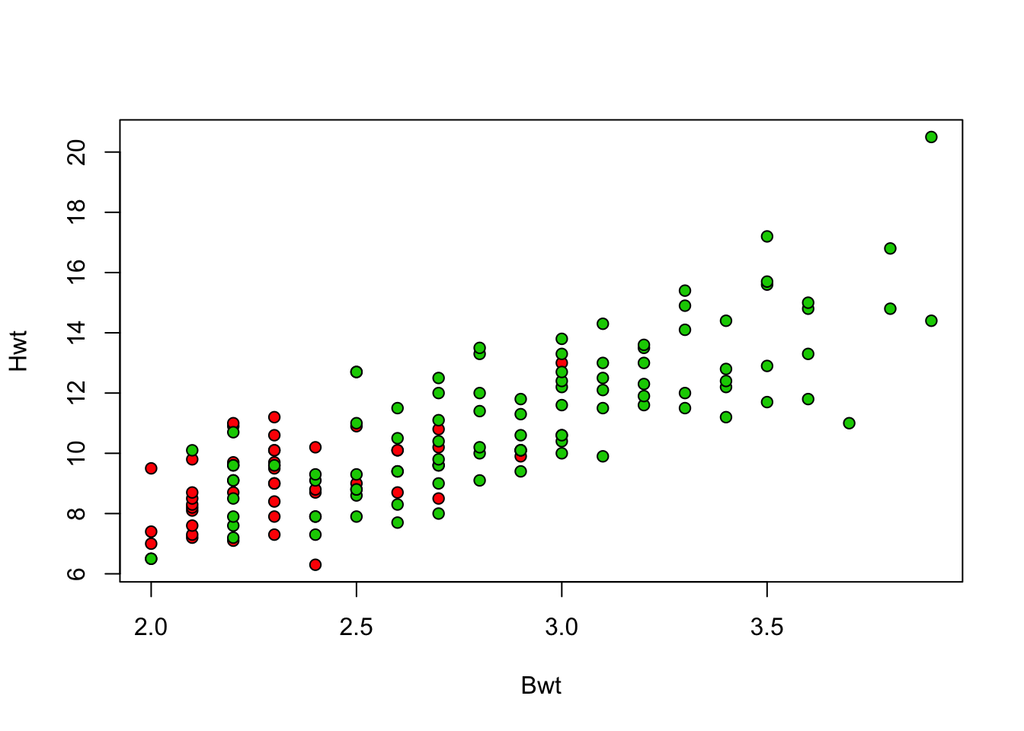

```r
library(MASS)
data(cats)
help(cats)
plot(cats[2:3], pch = 21, bg = c("red", "green3")[unclass(cats$Sex)])
```

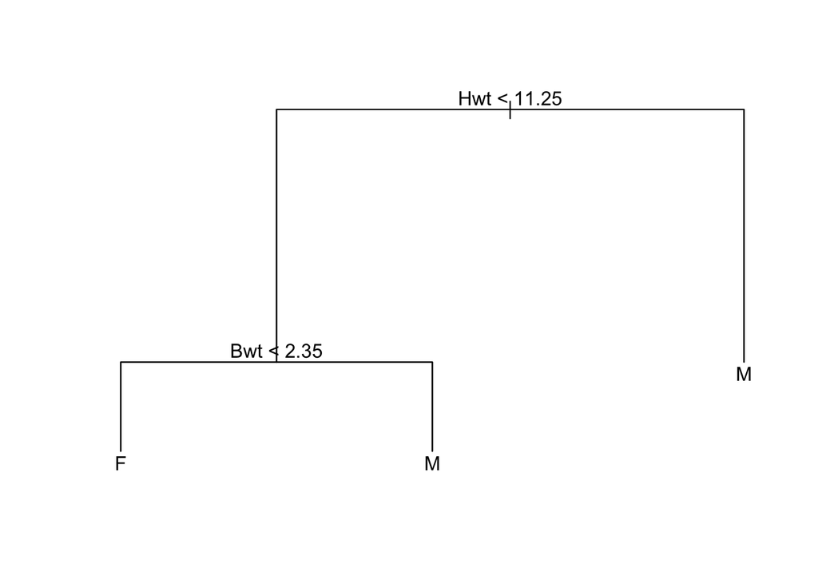

```r
cats_model <- tree(Sex~., data = cats, control=tree.control(nrow(cats), mindev = 0.05))
plot(cats_model)
text(cats_model)
```

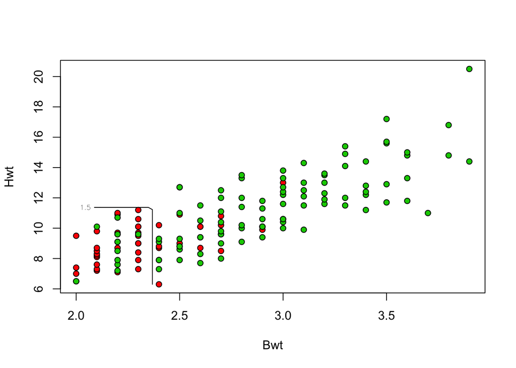

```r
x1 <- seq(min(cats$Bwt), max(cats$Bwt), length = 50)
x2 <- seq(min(cats$Hwt), max(cats$Hwt), length = 50)
Feature_x1_to_x2 <- expand.grid(Bwt = x1, Hwt = x2)
Feature_x1_to_x2_Class <- apply(predict(cats_model,Feature_x1_to_x2),1,
                                function(one_row) return(which(one_row == max(one_row))))
plot(cats[2:3], pch = 21, bg = c("red", "green3")[unclass(cats$Sex)])
contour(x1,x2,matrix(Feature_x1_to_x2_Class,length(x1)),add = T, levels = 1.5, labex = 0)
```

Change mindev

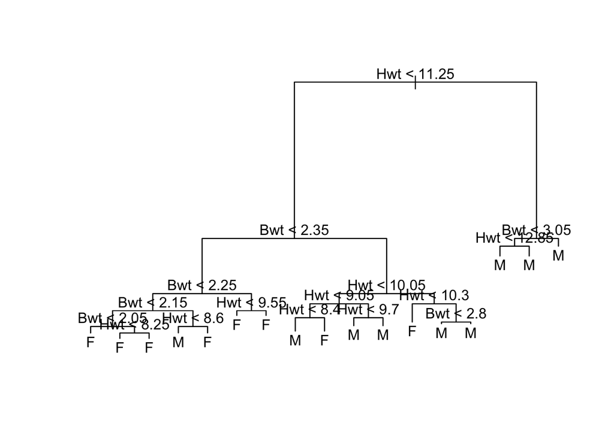

```r
cats_model <- tree(Sex~., data = cats, control=tree.control(nrow(cats), mindev = 0.001))
plot(cats_model)
text(cats_model)
```

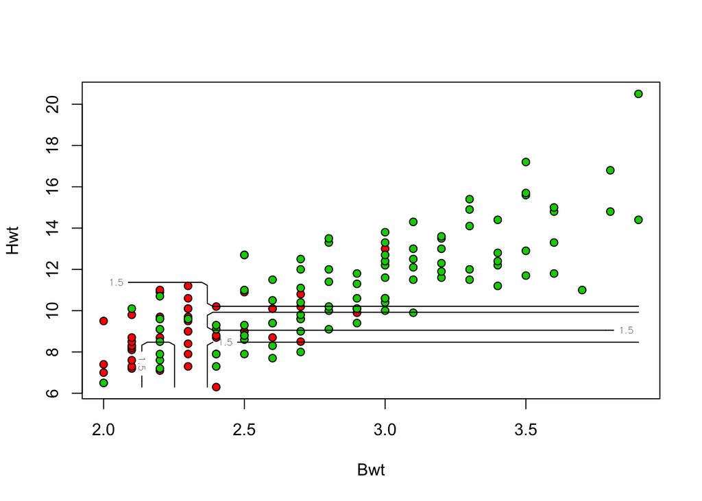

```r
Feature_x1_to_x2 <- expand.grid(Bwt = x1, Hwt = x2)
Feature_x1_to_x2_Class <- apply(predict(cats_model,Feature_x1_to_x2),1,
                                function(one_row) return(which(one_row == max(one_row))))
plot(cats[2:3], pch = 21, bg = c("red", "green3")[unclass(cats$Sex)])
contour(x1,x2,matrix(Feature_x1_to_x2_Class,length(x1)),add = T, levels = 1.5, labex = 0)
```